# Get started with lunarcast

lunarcast forecasts monthly and quarterly series that react to **moving holidays**: holidays such as Eid al-Fitr, Eid al-Adha, the Chinese New Year or Easter, whose Gregorian date changes every year. This vignette walks through a complete analysis. The method is explained in `vignette("theory")` and compared with the classical calendar variation model in `vignette("classic-vs-lunarcast")`.

## Installation

```r
# install.packages("pak")
pak::pak("novrisuhermi/lunarcast")

# or, with vignettes
# install.packages("remotes")
remotes::install_github("novrisuhermi/lunarcast", build_vignettes = TRUE)
```

## The data

The package contains `sapi`, the monthly Google Trends index for “sapi” (cattle) in Indonesia. Interest peaks before Eid al-Adha, when cattle are bought for the sacrifice.

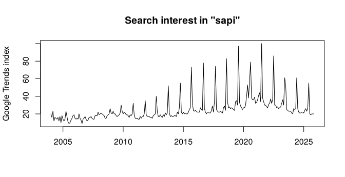

```r
library(lunarcast)
plot(sapi, xlab = "", ylab = "Google Trends index",
     main = "Search interest in \"sapi\"")
```

Two features make this series hard: the peaks move to an earlier month every few years, and their size changes, from almost nothing in 2004 to more than three times the usual level in the late 2010s.

## Step 1: holiday dates

```r
adha <- holiday_dates("idul_adha")
tail(adha, 4)
```

```
#> [1] "2024-06-17" "2025-06-06" "2026-05-27" "2027-05-17"
```

`holiday_dates()` gives the Indonesian dates of Eid al-Adha, Eid al-Fitr and the Chinese New Year from 2004 to 2027, and `easter_dates()` computes Easter and the holidays that follow from it. Any other holiday is simply a vector of dates.

```r
easter_dates(2025:2026, offset = -2)   # Good Friday
```

```
#> [1] "2025-04-18" "2026-04-03"
```

```r
my_holiday <- as.Date(c("2024-03-11", "2025-03-29", "2026-03-19"))
```

## Step 2: from dates to regressors

A holiday influences the days around it, not a calendar month. `holiday_window()` computes the share of a window of days around each occurrence that falls in each month.

```r
w <- holiday_window(adha, window = c(-3, 7), y = sapi)
window(w, start = c(2020, 6), end = c(2020, 9))
```

```
#>            Jun       Jul       Aug       Sep
#> 2020 0.0000000 0.3636364 0.6363636 0.0000000
```

Eid al-Adha fell on 31 July 2020. The window from three days before to seven days after puts 36% of the holiday in July and 64% in August, where the searches indeed peaked. A monthly dummy would have put everything in July. You do not need to build these regressors yourself; `lunarcast()` does it and chooses the window.

## Step 3: fit the automatic model

```r
hol <- list(adha  = holiday_dates("idul_adha"),
            fitri = holiday_dates("idul_fitri"))
fit <- lunarcast(sapi, hol)
fit
```

```
#> lunarcast: Regression with ARIMA(5,1,1)(2,0,0)[12] errors | AICc = -296.9
#> Structure (cv, 1se): stochastic + SARMA(2,0,0), d = 1
#> Cross-validated RMSE of the candidate structures:
#>                  structure RMSE    SE
#>  stochastic + SARMA(2,0,0) 4.53 1.017
#>  stochastic + fourier(K=4) 5.08 0.821
#>         stochastic + dummy 5.10 0.795
#>          stochastic + none 5.86 0.962
#>
#> adha: two-level effect, window [-3, +7] days, level 2 = wmean (CV-RMSE 0.13)
#>       event   alpha     se ratio
#>  2004-02-01 -0.0712 0.1816 0.931
#>  2005-01-21  0.1664 0.1196 1.181
#>  2006-01-10 -0.1558 0.1029 0.856
#>  2006-12-31 -0.5505 0.1860 0.577
#>  2007-12-20  0.1819 0.0964 1.199
#>  2008-12-08  0.2440 0.0978 1.276
#>  2009-11-27  0.4874 0.1452 1.628
#>  2010-11-17  0.5180 0.0976 1.679
#>  2011-11-06  0.5801 0.1003 1.786
#>  2012-10-26  0.8234 0.1213 2.278
#>  2013-10-15  0.9386 0.0980 2.556
#>  2014-10-05  0.8655 0.0993 2.376
#>  2015-09-24  0.9935 0.1108 2.701
#>  2016-09-12  1.0087 0.1012 2.742
#>  2017-09-01  1.2335 0.1277 3.433
#>  2018-08-22  1.1742 0.0980 3.236
#>  2019-08-11  1.1629 0.0981 3.199
#>  2020-07-31  1.1167 0.1392 3.055
#>  2021-07-20  1.0764 0.0985 2.934
#>  2022-07-10  1.0088 0.0979 2.742
#>  2023-06-29  1.1770 0.1382 3.245
#>  2024-06-17  0.8363 0.1013 2.308
#>  2025-06-06  0.8326 0.1057 2.299
#>
#> fitri: constant effect, window [-28, +3] days
#>  alpha     se ratio
#>  0.147 0.0346  1.16
```

How to read the output:

- The first line is the fitted regression with ARIMA errors and its AICc.
- `Structure` is the selected trend and seasonal structure. The trend type comes from KPSS tests; the table below it lists the candidate seasonal structures with their cross-validated RMSE and its standard error. The default one-SE rule takes the simplest structure within one standard error of the best.
- For each holiday you see whether its effect is `constant` or `two-level`, the selected window in days around the holiday and, for two-level effects, the level-2 rule used to forecast the next effect.
- `ratio` is the multiplicative effect $e^{\alpha}$: 2.5 means that the holiday (when its whole window falls in one month) multiplies the level of that month by 2.5.

## Step 4: inspect the holiday effects

```r
eff <- holiday_effects(fit)
head(eff, 4)
```

```
#>   holiday      type      event      alpha        se     ratio
#> 1    adha two-level 2004-02-01 -0.0712326 0.1815594 0.9312453
#> 2    adha two-level 2005-01-21  0.1663557 0.1196175 1.1809931
#> 3    adha two-level 2006-01-10 -0.1557509 0.1028979 0.8557724
#> 4    adha two-level 2006-12-31 -0.5505277 0.1859972 0.5766455
```

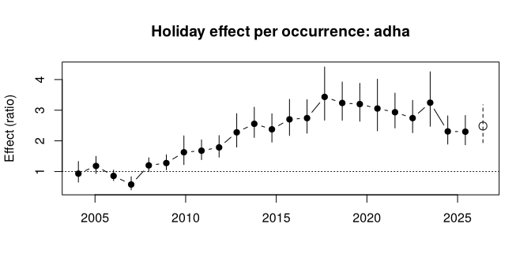

```r
plot(fit)
```

Each point is the effect of one Eid al-Adha with its 95% confidence interval; the open circle is the forecast for the next occurrence. The effect grew until the late 2010s and has declined since, which a single constant effect cannot represent.

## Step 5: forecast

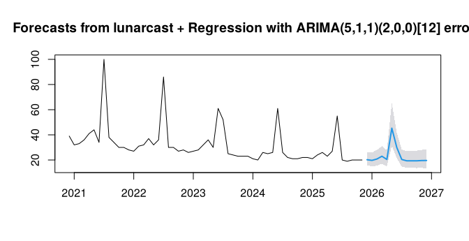

```r
fc <- forecast(fit, h = 13)
plot(fc, include = 60)
```

```r
fc$future_effects
```

```
#> $adha
#>        event     alpha       se method    ratio
#> 1 2026-05-27 0.9095093 0.126112  wmean 2.483104
```

```r
round(cbind(forecast = fc$mean, lower = fc$lower[, 1],
            upper = fc$upper[, 1]), 1)
```

```
#>          forecast lower upper
#> Dec 2025     20.2  15.8  25.9
#> Jan 2026     19.7  15.0  25.9
#> Feb 2026     20.8  15.4  28.0
#> Mar 2026     23.0  17.0  31.0
#> Apr 2026     20.4  15.0  27.8
#> May 2026     45.3  31.3  65.4
#> Jun 2026     29.9  21.5  41.7
#> Jul 2026     20.4  14.8  28.2
#> Aug 2026     19.4  13.8  27.1
#> Sep 2026     19.3  13.7  27.2
#> Oct 2026     19.3  13.6  27.5
#> Nov 2026     19.6  13.7  27.9
#> Dec 2026     19.6  13.4  28.6
```

The forecast is the median on the original scale with a 95% interval that includes the uncertainty about the next holiday effect. `fc$future_effects` shows the effect used for each new occurrence and the rule that produced it.

### Scenarios

To ask “what if the next Eid al-Adha doubles the level?”, fix its effect:

```r
sc <- forecast(fit, h = 13, level2 = list(adha = log(2)))
round(cbind(model = fc$mean, scenario = sc$mean)[5:7, ], 1)
```

```
#>      model scenario
#> [1,]  20.4     20.4
#> [2,]  45.3     37.6
#> [3,]  29.9     27.1
```

## Taking control of the automatic choices

Every automatic choice can be fixed, which also makes fitting much faster.

| Argument | What it controls | Example |
| --- | --- | --- |
| `window` | days around each holiday | `window = list(adha = c(-3, 7), fitri = c(-28, 3))` |
| `window` | several windows for one holiday, one effect each | `window = list(adha = list(before = c(-14, -1), holiday = c(0, 3)))` |
| `effect` | constant or two-level effect | `effect = list(adha = "two-level", fitri = "constant")` |
| `trend`, `season` | trend and seasonal structure | `trend = "stochastic", season = "none"`; `trend = "cv"` compares both trend types |
| `select` | how the structure is chosen | `select = "aicc"` |
| `cv_rule`, `cv_years` | cross-validation rule and origins | `cv_rule = "min", cv_years = 3` |
| `level2` | rule for future effects | `level2 = list(adha = "rw")` |
| `outliers` | detect AO, LS and TC outliers | `outliers = TRUE` |
| `lambda` | transformation (`0` = log) | `lambda = NULL` for additive effects |

```r
fast <- lunarcast(sapi, hol,
                  window = list(adha = c(-3, 7), fitri = c(-28, 3)),
                  effect = list(adha = "two-level", fitri = "constant"),
                  trend = "stochastic", season = "none")
fast
```

```
#> lunarcast: Regression with ARIMA(5,1,1) errors | AICc = -281.2
#> Structure (fixed): stochastic + none, d = 1
#>
#> adha: two-level effect, window [-3, +7] days, level 2 = wmean (CV-RMSE 0.12)
#>       event  alpha     se ratio
#>  2004-02-01 -0.227 0.1864 0.797
#>  2005-01-21  0.140 0.1116 1.150
#>  2006-01-10 -0.188 0.1043 0.828
#>  2006-12-31 -0.412 0.1886 0.663
#>  2007-12-20  0.220 0.0993 1.246
#>  2008-12-08  0.269 0.0994 1.309
#>  2009-11-27  0.544 0.1537 1.723
#>  2010-11-17  0.524 0.1003 1.689
#>  2011-11-06  0.605 0.1003 1.831
#>  2012-10-26  0.860 0.1253 2.363
#>  2013-10-15  0.973 0.0998 2.645
#>  2014-10-05  0.885 0.1001 2.424
#>  2015-09-24  1.080 0.1129 2.944
#>  2016-09-12  1.141 0.0994 3.129
#>  2017-09-01  1.353 0.1318 3.871
#>  2018-08-22  1.123 0.0993 3.074
#>  2019-08-11  1.152 0.1002 3.166
#>  2020-07-31  1.034 0.1473 2.811
#>  2021-07-20  1.000 0.0993 2.718
#>  2022-07-10  0.957 0.0997 2.604
#>  2023-06-29  1.151 0.1458 3.162
#>  2024-06-17  0.891 0.0994 2.438
#>  2025-06-06  0.855 0.1011 2.350
#>
#> fitri: constant effect, window [-28, +3] days
#>  alpha     se ratio
#>  0.159 0.0303  1.17
```

## The classical model

The classical calendar variation model, with a dummy for the holiday month and the same effect every year, is available in the six structures m1 to m6:

```r
m6 <- calvar_classic(sapi, adha, trend = "stochastic", season = "stochastic")
m6
```

```
#> Classical calendar variation model: stochastic trend + stochastic seasonality
#> Calendar design: holiday dummy
#> Regression with ARIMA(1,1,1)(1,0,2)[12] errors | AICc = 1708.9
#> Holiday effects (same every year, original scale):
#>     term estimate   se
#>  holiday    18.92 2.01
```

Besides the holiday-month dummy, the classical model has two other calendar designs: `design = "leadlag"` adds dummies for the months before and after the holiday, and `design = "window"` uses proportional windows (Bell and Hillmer, 1983), by default the days before the holiday, whose number is chosen by AICc, and the holiday with the three following days:

```r
calvar_classic(sapi, adha, trend = "stochastic", season = "stochastic",
               design = "window")
```

```
#> Classical calendar variation model: stochastic trend + stochastic seasonality
#> Calendar design: proportional windows: before [-14, -1] days, holiday [0, +3] days
#> Regression with ARIMA(2,1,2)(2,0,0)[12] errors | AICc = 1654
#> Holiday effects (same every year, original scale):
#>     term estimate    se
#>   before    5.895 2.185
#>  holiday   22.082 1.651
#> AICc of the candidate windows:
#>  window  w    AICc
#>  before  7 1658.12
#>  before 14 1653.96
#>  before 21 1655.52
#>  before 28 1656.46
```

`calvar_classic_all()` fits all six structures at once, for one or several designs, and `forecast()` works for both kinds of models. The approaches are compared in `vignette("classic-vs-lunarcast")`.

## Evaluating forecasts

`rolling_origin()` refits models at the end of every year and forecasts the next year; `rolling_summary()` reports the RMSE overall, in holiday months, in years in which the holiday moved to another month, and the mean and median of the yearly RMSEs.

```r
models <- list(
  classic_m6 = function(y, h)
    forecast(calvar_classic(y, adha, "stochastic", "stochastic"), h = h)$mean,
  lunarcast  = function(y, h) forecast(lunarcast(y, hol), h = h)$mean
)
r <- rolling_origin(sapi, adha, models, first = 2012)
rolling_summary(r)
```

[output not shown]

`forecast_accuracy()` gives RMSE, MAE, MAPE and sMAPE for a single test period.